# Loading and analysing spatial data with the `sf` package

P. Roudier

26 June 2017

Soil data has its specificities, but generally speaking we can get away with treating it like a spatial dataset for a significant part of the analysis workflow. This is why in this tutorial, we will present tools to read and process spatial data.

A lot (most?) of soil data is stored as using spatial formats – for better or worse. While the soil profile is a specific case (we can consider it as a set of horizons generated from a spatial point located at the surface of our planet, soil surveys, landsacpe attributes and enviornemental covariates are best represented as spatial datasets.

When reading such data, the main study cases are:

- Text file formats, such as `txt` or `csv`
- Spatial file formats, such as ESRI Shapefiles or Geopackages
- Database (spatial or not), such as Postgres, PostGIS, etc.

In this tutorial, we will mostly cover the two first cases.

# Packages

## In the old days…

- `sp`: provides a set of dedicated classes for the different vector and raster datatypes , and *some* analysis tools (overlays, etc.),
- `rgdal`: input/output library built over GDAL/OGR to read and write spatial data,
- `rgeos`: geometry library built over GEOS for all geometry operations (union, intersections, buffer, etc).

## The bleeding edge ⚡

Recently (this year), a new package has been introduced to manipulate vector data: `sf` (for Simple Features). It’s a pretty interesting improvement on `sp`/`rgdal`/`rgeos`, and we will focus on it in this tutorial.

In a few words, here’s what is interesting about `sf`:

- It’s providing users with one **unique** class for all vector types,
- It’s based on **Simple Features**, a formal standard (ISO 19125-1:2004) widely used in the GIS world that describes how objects in the real world can be represented,
- The main class provided by `sf` is a **`data.frame`** – which means that a lot of data analysis methods are readily available,
- It combines the capabilities of `sp`, `rgdal`, and `rgeos` under one **unique package**,
- It is easier to install on some platforms than `rgdal`,
- It is **much faster**, and **scales better** than `sp` and `rgdal` — the upcoming version will include **spatial indexing**!

# Simple Features?

## Quick definition

According to the standard:

> “A simple feature is defined by the OpenGIS Abstract specification to have **both spatial and non-spatial attributes**. Spatial attributes are **geometry** valued, and simple features are based on 2D geometry with linear interpolation between vertices.”

Basically, spatial is not that special anymore: spatial attributes can be described as a *geometry*, which is just another attribute of the dataset.

Several types of geometry can be implemented using this standard: `POINT`, `LINESTRING`, `POLYGON`, `MULTIPOINT`, `MULTILINESTRING`, `MULTIPOLYGON`, `GEOMETRYCOLLECTION`. There’s also more fancy stuff like `CURVEPOLYGON`, etc.

## Implementation in R

Simple Features are represented using WKT/WKB (Well Known Text/Well Known Binary). It looks like:

```
## POINT(0 1)
```

```
## MULTIPOINT(1 6, 2 7, 3 8, 4 9, 5 10)
```

```
## MULTIPOLYGON(((0 0, 10 0, 10 10, 0 10, 0 0), (1 1, 1 2, 2 2, 2 1, 1 1), (5 5, 5 6, 6 6, 6 5, 5 5)), ((12 12, 22 12, 22 22, 12 22, 12 12), (13 13, 13 14, 14 14, 14 13, 13 13)), ((24 24, 34 24, 34 34, 24 34, 24 24)))
```

Simple Features are represented by `sf` as a `data.frame`. The spatial attributes of the Simple Features (or `geometry`) are represenetd using WKT. Technically speaking, there are 3 types of classes implemented by the `sf` package:

- `sf` is the `data.frame` with spatial attributes,
- `sfc` is the column storing the geometries of the different records in the `data.frame`,
- `sfg` is the geometry of each individual record.

The functions provided by `sf` are prefixed by `st_` — similarly to *PostGIS*. That makes it easy to search for them on the command line too.

# Reading and writing spatial datasets

## Loading spatial data from text files

It is very often that point data (such as profiles) is exchanged using a text delimited format such as CSV.

### Reading text files

CSV and TXT files can be read using the classic `read.csv`, `read.delim`, etc., in `base` R. however, the `readr` package — from the `tidyverse` — does provide interesting alternatives that are much faster in read and write.

```r
library(tidyverse)

df <- read_csv('./path/to/my/file.csv')
```

### Converting `data.frame` to Simple Features

Let’s take the example dataset `meuse` from the `sp` package. `meuse` is a `data.frame` — similar to what could have been read from a CSV file using `read_csv`:

```r
data('meuse', package = "sp")
head(meuse)
```

```
##        x      y cadmium copper lead zinc  elev       dist   om ffreq soil
## 1 181072 333611    11.7     85  299 1022 7.909 0.00135803 13.6     1    1
## 2 181025 333558     8.6     81  277 1141 6.983 0.01222430 14.0     1    1
## 3 181165 333537     6.5     68  199  640 7.800 0.10302900 13.0     1    1
## 4 181298 333484     2.6     81  116  257 7.655 0.19009400  8.0     1    2
## 5 181307 333330     2.8     48  117  269 7.480 0.27709000  8.7     1    2
## 6 181390 333260     3.0     61  137  281 7.791 0.36406700  7.8     1    2
##   lime landuse dist.m
## 1    1      Ah     50
## 2    1      Ah     30
## 3    1      Ah    150
## 4    0      Ga    270
## 5    0      Ah    380
## 6    0      Ga    470
```

The easiest way to modifiy this `data.frame` so that its coordinates (`x` and `y`) are used to generate a `geometry` column is using `st_as_sf` (“as simple feature”):

```r
ms <- st_as_sf(
  meuse,
  coords = c('x', 'y'),
  crs = "+init=epsg:28992"
)

ms
```

```
## Simple feature collection with 155 features and 12 fields
## geometry type:  POINT
## dimension:      XY
## bbox:           xmin: 178605 ymin: 329714 xmax: 181390 ymax: 333611
## epsg (SRID):    28992
## proj4string:    +proj=sterea +lat_0=52.15616055555555 +lon_0=5.38763888888889 +k=0.9999079 +x_0=155000 +y_0=463000 +ellps=bessel +towgs84=565.4171,50.3319,465.5524,-0.398957388243134,0.343987817378283,-1.87740163998045,4.0725 +units=m +no_defs
## First 20 features:
##    cadmium copper lead zinc  elev       dist   om ffreq soil lime landuse
## 1     11.7     85  299 1022 7.909 0.00135803 13.6     1    1    1      Ah
## 2      8.6     81  277 1141 6.983 0.01222430 14.0     1    1    1      Ah
## 3      6.5     68  199  640 7.800 0.10302900 13.0     1    1    1      Ah
## 4      2.6     81  116  257 7.655 0.19009400  8.0     1    2    0      Ga
## 5      2.8     48  117  269 7.480 0.27709000  8.7     1    2    0      Ah
## 6      3.0     61  137  281 7.791 0.36406700  7.8     1    2    0      Ga
## 7      3.2     31  132  346 8.217 0.19009400  9.2     1    2    0      Ah
```

[output cut: 34 more lines]

There is a simple plotting funtion including in `sf`. It is very similar to the old `sp::spplot`:

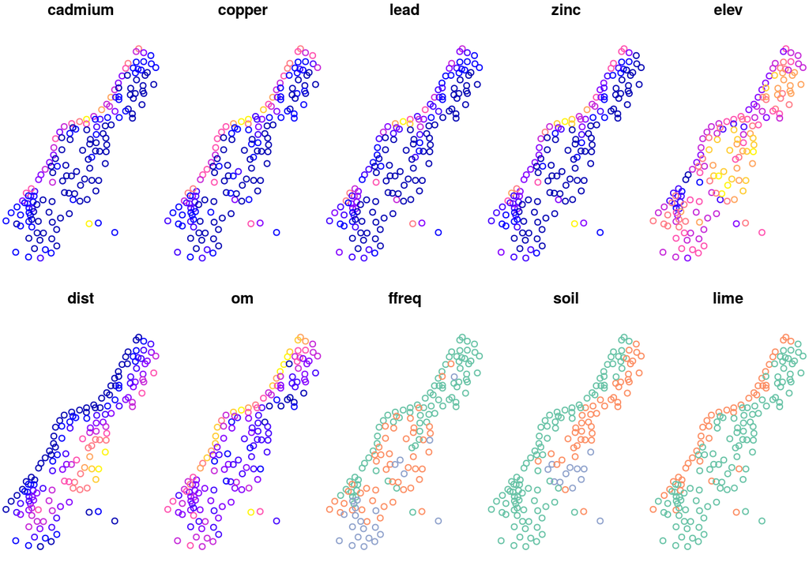

```r
plot(ms)
```

## Loading spatial data formats

A wide selecton of spatial data formats can be read using the `st_read` command (it’s using GDAL/OGR behind the scenes). Unlike `readOGR` from the `rgdal` package, generally the command can guess which driver it should use.

```r
file_name <- system.file("shape/nc.shp", package="sf")
nc <- st_read(file_name)
print(nc)
```

```
## Simple feature collection with 100 features and 14 fields
## geometry type:  MULTIPOLYGON
## dimension:      XY
## bbox:           xmin: -84.32385 ymin: 33.88199 xmax: -75.45698 ymax: 36.58965
## epsg (SRID):    4267
## proj4string:    +proj=longlat +datum=NAD27 +no_defs
## First 20 features:
##     AREA PERIMETER CNTY_ CNTY_ID        NAME  FIPS FIPSNO CRESS_ID BIR74
## 1  0.114     1.442  1825    1825        Ashe 37009  37009        5  1091
## 2  0.061     1.231  1827    1827   Alleghany 37005  37005        3   487
## 3  0.143     1.630  1828    1828       Surry 37171  37171       86  3188
## 4  0.070     2.968  1831    1831   Currituck 37053  37053       27   508
## 5  0.153     2.206  1832    1832 Northampton 37131  37131       66  1421
## 6  0.097     1.670  1833    1833    Hertford 37091  37091       46  1452
## 7  0.062     1.547  1834    1834      Camden 37029  37029       15   286
```

[output cut: 34 more lines]

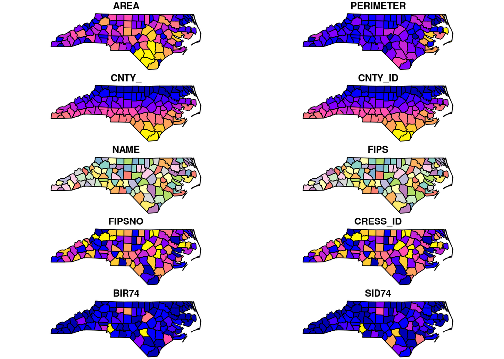

```r
plot(nc)
```

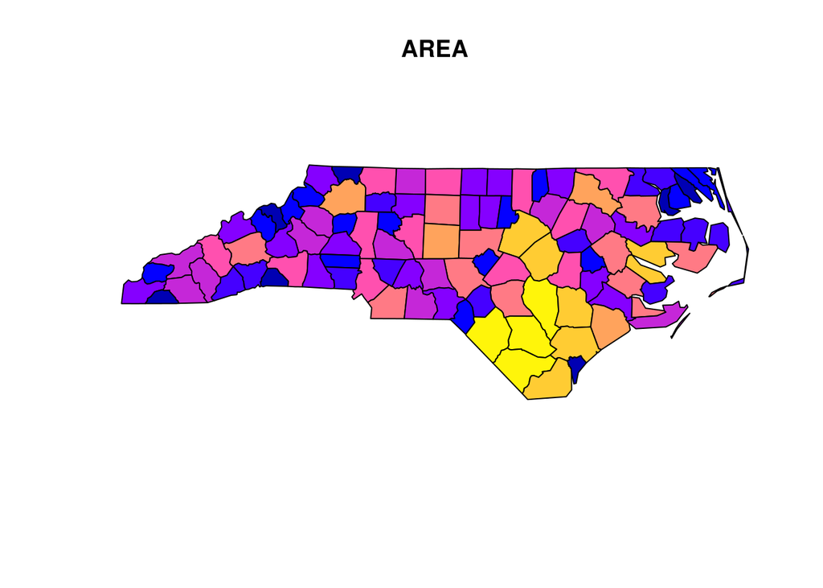

```r
plot(nc['AREA'])
```

Its counterpart is `st_write` and is just as easy to use:

```r
st_write(nc, "nc.shp")
st_write(nc, "nc.shp", delete_layer = TRUE)

# Note that write_st erases existing layers silently:
write_sf(nc, "nc.shp")
```

The drivers available on your machine can be printed using the `st_drivers` command:

```r
my_drivers <- st_drivers()
head(my_drivers)
```

```
##                          name                                  long_name
## PCIDSK                 PCIDSK                       PCIDSK Database File
## netCDF                 netCDF                 Network Common Data Format
## JP2OpenJPEG       JP2OpenJPEG JPEG-2000 driver based on OpenJPEG library
## PDF                       PDF                             Geospatial PDF
## ESRI Shapefile ESRI Shapefile                             ESRI Shapefile
## MapInfo File     MapInfo File                               MapInfo File
##                write  copy is_raster is_vector
## PCIDSK          TRUE FALSE      TRUE      TRUE
## netCDF          TRUE  TRUE      TRUE      TRUE
## JP2OpenJPEG    FALSE  TRUE      TRUE      TRUE
## PDF             TRUE  TRUE      TRUE      TRUE
## ESRI Shapefile  TRUE FALSE     FALSE      TRUE
## MapInfo File    TRUE FALSE     FALSE      TRUE
```

## The case of databases

GDAL/OGR can read data from databases — so `sf` does too:

```r
# Using GDAL
meuse <- st_read("PG:dbname=postgis", "meuse")

# Using the Postgres package
library(RPostgreSQL)

# Connect to a PostGIS instance
conn <- dbConnect(PostgreSQL(), dbname = "postgis")

# Use this conection to make a query
x <- st_read_db(conn, "meuse", query = "SELECT * FROM meuse LIMIT 3;")
x <- st_read_db(conn, table = "public.meuse")

print(st_crs(x)) # SRID resolved by the database, not by GDAL!

# Close the DB connection
dbDisconnect(conn)

# Write spatial data as SQLite database
sf::write_sf(nc, 'nc.sqlite')
```

# Manipulating Simple Features

Very roughly, the `sf` package provides two types of functions:

1. Spatial data operators (read, write, buffer, intersection, etc), prefixed by `st_`:

```
##  [1] "st_agr<-.sf"          "st_agr.sf"            "st_as_sf.sf"
##  [4] "st_bbox.sf"           "st_boundary.sf"       "st_buffer.sf"
##  [7] "st_cast.sf"           "st_centroid.sf"       "st_convex_hull.sf"
## [10] "st_coordinates.sf"    "st_crs<-.sf"          "st_crs.sf"
## [13] "st_difference.sf"     "st_geometry<-.sf"     "st_geometry.sf"
## [16] "st_intersection.sf"   "st_is.sf"             "st_line_merge.sf"
## [19] "st_make_valid.sf"     "st_polygonize.sf"     "st_precision.sf"
## [22] "st_segmentize.sf"     "st_set_precision.sf"  "st_simplify.sf"
## [25] "st_split.sf"          "st_sym_difference.sf" "st_transform.sf"
## [28] "st_triangulate.sf"    "st_union.sf"          "st_voronoi.sf"
## [31] "st_zm.sf"
```

```
##  [1] "aggregate.sf"                "cbind.sf"
##  [3] "coerce,oldClass,S3-method"   "coerce,sf,Spatial-method"
##  [5] "coerce,Spatial,sf-method"    "initialize,oldClass-method"
##  [7] "merge.sf"                    "plot.sf"
##  [9] "print.sf"                    "rbind.sf"
## [11] "[.sf"                        "[[<-.sf"
## [13] "$<-.sf"                      "show,oldClass-method"
## [15] "slotsFromS3,oldClass-method"
```

## `tidy` verbs

`sf` is very well integrated with `dplyr` and the `tidyverse`: remember that Simple Features as implemented by `sf` are fundamentally just `data.frame`s!

```r
library(dplyr)
# Example: joining non-spatial attributes
#
additional_data <- data.frame(
  CNTY_ID = nc$CNTY_ID,
  my_data <- runif(nrow(nc))
)

left_join(nc, additional_data, by = 'CNTY_ID')
```

```
## Simple feature collection with 100 features and 15 fields
## geometry type:  MULTIPOLYGON
## dimension:      XY
## bbox:           xmin: -84.32385 ymin: 33.88199 xmax: -75.45698 ymax: 36.58965
## epsg (SRID):    4267
## proj4string:    +proj=longlat +datum=NAD27 +no_defs
## First 20 features:
##     AREA PERIMETER CNTY_ CNTY_ID        NAME  FIPS FIPSNO CRESS_ID BIR74
## 1  0.114     1.442  1825    1825        Ashe 37009  37009        5  1091
## 2  0.061     1.231  1827    1827   Alleghany 37005  37005        3   487
## 3  0.143     1.630  1828    1828       Surry 37171  37171       86  3188
## 4  0.070     2.968  1831    1831   Currituck 37053  37053       27   508
## 5  0.153     2.206  1832    1832 Northampton 37131  37131       66  1421
## 6  0.097     1.670  1833    1833    Hertford 37091  37091       46  1452
## 7  0.062     1.547  1834    1834      Camden 37029  37029       15   286
```

[output cut: 55 more lines]

`sf` is also providing verbs that are **adapted** to working with `geometries`. For example `summarise` will also operate a spatial union:

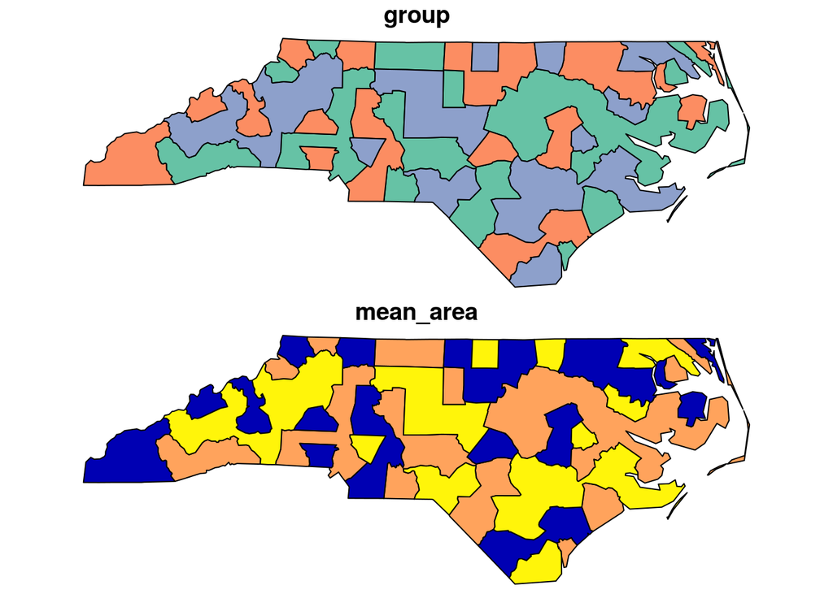

```r
nc %>%
  mutate(
    group = sample(LETTERS[1:3], size = n(), replace = TRUE),
    area = st_area(.), # Note the computation of area on the fly
    sqrt_area = sqrt(area)
  ) %>%
  group_by(group) %>%
  summarise(mean_area = mean(sqrt_area)) %>%
  plot
```

## Projection

The main functions are `st_crs`, which retrieves the Coordinate Reference System (CRS) of the `sf` object, and `st_transform`, which allows to re-project the dataset into a different CRS.

The CRS can be specified as an EPSG number (that is: an integer), or as a character string follwoing the Proj.4 standard.

```r
# Retrieve projection information
st_crs(nc)
```

```
## $epsg
## [1] 4267
##
## $proj4string
## [1] "+proj=longlat +datum=NAD27 +no_defs"
##
## attr(,"class")
## [1] "crs"
```

```r
# Test whether data is projected or not
st_is_longlat(nc)
```

```
## [1] TRUE
```

```r
# Projection
#

# Using a Proj.4 string
nc_p <- st_transform(nc, crs = "+proj=lcc +lat_1=36.16666666666666 +lat_2=34.33333333333334 +lat_0=33.75 +lon_0=-79 +x_0=609601.22 +y_0=0 +ellps=GRS80 +towgs84=0,0,0,0,0,0,0 +units=m +no_defs")
# using an EPSG code
nc_p <- st_transform(nc, crs = 32119)

st_crs(nc_p)
```

```
## $epsg
## [1] 32119
##
## $proj4string
## [1] "+proj=lcc +lat_1=36.16666666666666 +lat_2=34.33333333333334 +lat_0=33.75 +lon_0=-79 +x_0=609601.22 +y_0=0 +ellps=GRS80 +towgs84=0,0,0,0,0,0,0 +units=m +no_defs"
##
## attr(,"class")
## [1] "crs"
```

## Geometry

The `sf` library wraps the capabilities of the GEOS (Geometry Engine Open Source) library — which is a very powerful piece of software used throughout the GIS industry, notably in PostGIS. The geometry functions in `sf` are prefixed using `st_` to mimic the PostGIS counterpart functions.

```r
# Area of features
st_area(nc)
```

```
## Units: m^2
##   [1] 1137388604  611077263 1423489919  694546292 1520740530  967727952
##   [7]  615942210  903650119 1179347051 1232769242 1136287383 1524655447
##  [13] 1427072339 1085967384  718190417 1894045426  524418608 1986966652
##  [19]  812293946  626337436  439717946  640703090  863300187 1276536764
##  [25] 1084141138 1697937846 1109973986 1800646340 1036414044  770546970
##  [31] 1423171283  585232978 1311628320 1225109692  800263351 1186420419
##  [37] 2194592880 1179139746 1550312884  690606074  665152821 1457875905
##  [43] 1340538971 1005743617  988324117 1163892506 2019778925 1810512144
##  [49]  944425951 1350102629 1685154840 1068192109 1691487743 2082117118
##  [55] 1447094476  943881740 2045540782 1420919020  707671880  653368537
##  [61] 1471077596 1436135571 1550981080 1186028306  788535203 1265443511
##  [67] 1829439189 1447873644  918216585 1312723474 1043728456  961860121
##  [73]  781910957 1046066043  986730350  917752685  601326678 1321916259
##  [79] 2437929994  833538942 1210326313 1738550168 1228689799 1648412173
##  [85] 1400582685  995107225 1678077407 2071844302 1228274216  519198288
##  [91] 1784932020  808600209 1978619669 2439553215 1264050755 2288682896
##  [97] 2181174167 2450241815  430695499 2165843695
```

```r
# Distances between features
st_distance(nc_p[1:3,], nc_p[3:6,])
```

```
## Units: m
##          [,1]     [,2]     [,3]     [,4]
## [1,] 25652.53 440561.1 299772.2 361529.5
## [2,]     0.00 409428.5 268944.3 332589.8
## [3,]     0.00 367555.5 227017.5 290297.1
```

```r
# Sanity check on the geometries
st_is_valid(nc[1:3,])
```

```
## [1] TRUE TRUE TRUE
```

The commands `st_intersects`, `st_disjoint`, `st_touches`, `st_crosses`, `st_within`, `st_contains`, `st_overlaps`, `st_equals`, `st_covers`, `st_covered_by`, `st_equals_exact` and `st_is_within_distance` are **logical tests**. They return a sparse matrix with matching (TRUE) indexes, or a full logical matrix:

```r
# Intersects
st_intersects(nc_p[1:5,], nc_p[1:4,])
```

```
## [[1]]
## [1] 1 2
##
## [[2]]
## [1] 1 2 3
##
## [[3]]
## [1] 2 3
##
## [[4]]
## [1] 4
##
## [[5]]
## integer(0)
```

```r
st_intersects(nc_p[1:5,], nc_p[1:4,], sparse = FALSE)
```

```
##       [,1]  [,2]  [,3]  [,4]
## [1,]  TRUE  TRUE FALSE FALSE
## [2,]  TRUE  TRUE  TRUE FALSE
## [3,] FALSE  TRUE  TRUE FALSE
## [4,] FALSE FALSE FALSE  TRUE
## [5,] FALSE FALSE FALSE FALSE
```

The commands `st_buffer`, `st_boundary`, `st_convexhull`, `st_union_cascaded`, `st_simplify`, `st_triangulate`, `st_polygonize`, `st_centroid`, `st_segmentize`, and `st_union` return **new geometries**, e.g.:

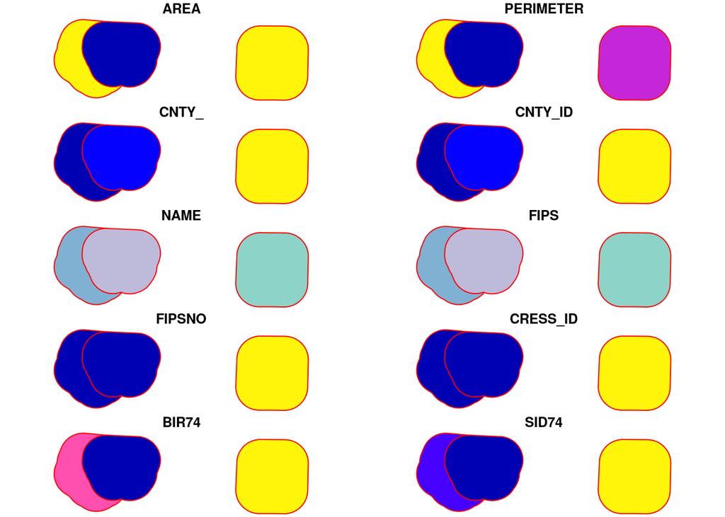

```r
buf <- st_buffer(nc_p[c(1, 2, 14),], dist = 30000)
plot(buf, border = 'red')
```

The `st_buffer` function computes a buffer outwards or inwards from features. Bonus trick: if you have invalid fatures, try to make a buffer of size zero

```r
fix <- st_buffer(corrupted, dist = 0)
```

Commands `st_intersection`, `st_union`, `st_difference`, `st_sym_difference` return **new geometries** that are a function of pairs of geometries:

```r
# Intersection
i <- st_intersection(nc_p[1:5,], nc_p[1:4,])
```

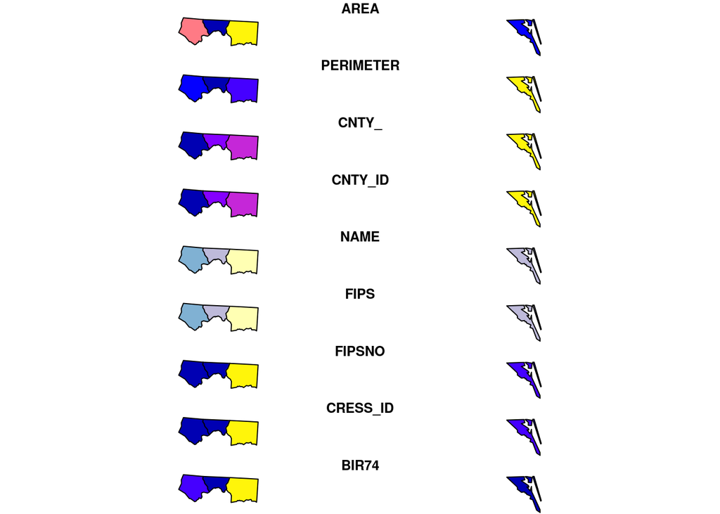

```r
plot(i)
```

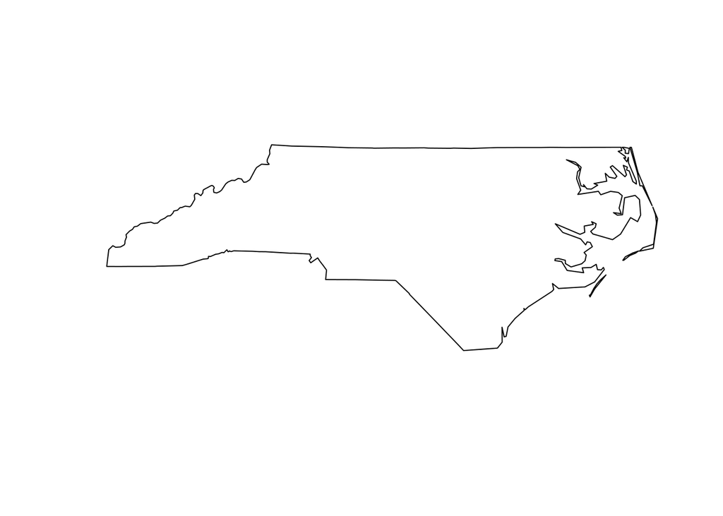

```r
# Union
u <- st_union(nc)
plot(u)
```

## Coercion to and from the `sp` classes

Note that you can convert `sf` objects back to either `data.frame` or one of the old `sp` classes very easily:

```r
# Convert to data.frame
as.data.frame(nc) %>% head
```

```
##    AREA PERIMETER CNTY_ CNTY_ID        NAME  FIPS FIPSNO CRESS_ID BIR74
## 1 0.114     1.442  1825    1825        Ashe 37009  37009        5  1091
## 2 0.061     1.231  1827    1827   Alleghany 37005  37005        3   487
## 3 0.143     1.630  1828    1828       Surry 37171  37171       86  3188
## 4 0.070     2.968  1831    1831   Currituck 37053  37053       27   508
## 5 0.153     2.206  1832    1832 Northampton 37131  37131       66  1421
## 6 0.097     1.670  1833    1833    Hertford 37091  37091       46  1452
##   SID74 NWBIR74 BIR79 SID79 NWBIR79                       geometry
## 1     1      10  1364     0      19 MULTIPOLYGON(((-81.47275543...
## 2     0      10   542     3      12 MULTIPOLYGON(((-81.23989105...
## 3     5     208  3616     6     260 MULTIPOLYGON(((-80.45634460...
## 4     1     123   830     2     145 MULTIPOLYGON(((-76.00897216...
## 5     9    1066  1606     3    1197 MULTIPOLYGON(((-77.21766662...
## 6     7     954  1838     5    1237 MULTIPOLYGON(((-76.74506378...
```

```r
# convert to one of the sp classes
as(nc, "Spatial") %>% summary
```

```
##                   Length                    Class                     Mode
##                      100 SpatialPolygonsDataFrame                       S4
```

# `ggplot2` compatibility

In the upcoming version of `ggplot2` (note that I’m running **the development version**), `sf` object can be plotted very easily using `geom_sf` — so the incredible power of this plotting sytem can be takn advantage of:

```r
library(ggplot2)
packageVersion('ggplot2')
```

```
## [1] '2.2.1.9000'
```

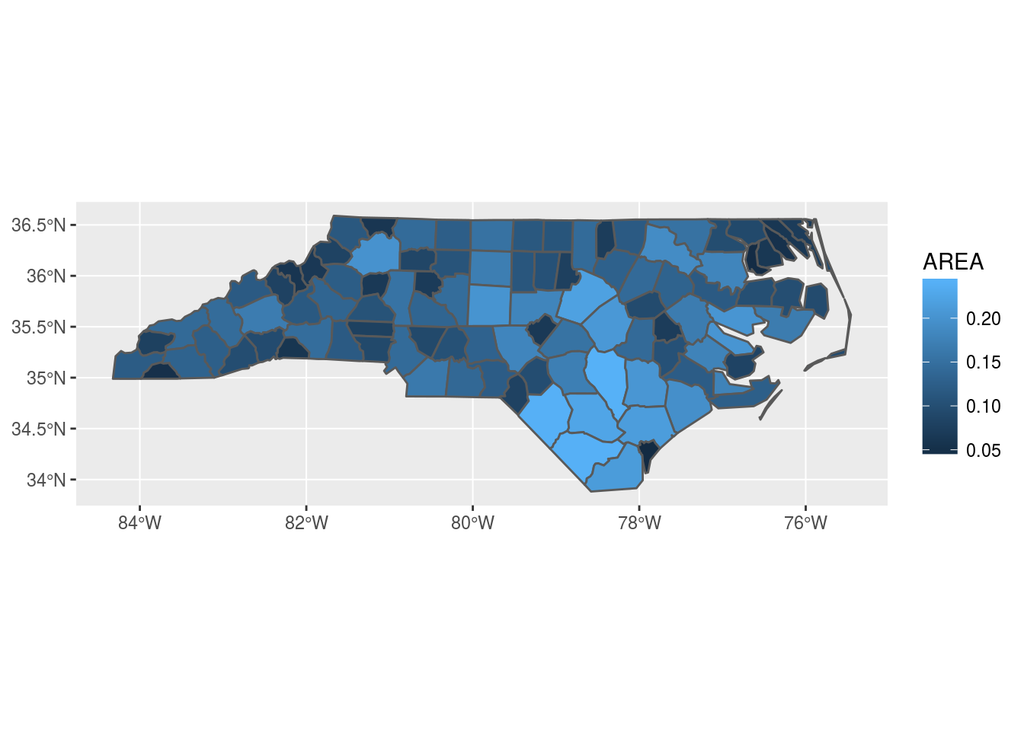

```r
# Unprojected data
ggplot(nc) +
  geom_sf(aes(fill = AREA))
```

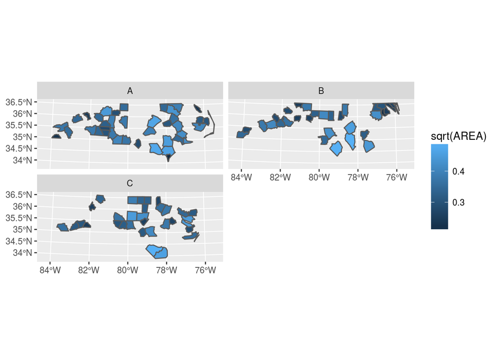

```r
# Facetting (on projected data this time!)

nc_grouped <- nc_p %>%
  mutate(
    # Creating a (random) group attribute
    group = sample(LETTERS[1:3], size = n(), replace = TRUE)
  )

ggplot(nc_grouped) +
  geom_sf(aes(fill = sqrt(AREA))) +
  facet_wrap(~group, ncol = 2)
```

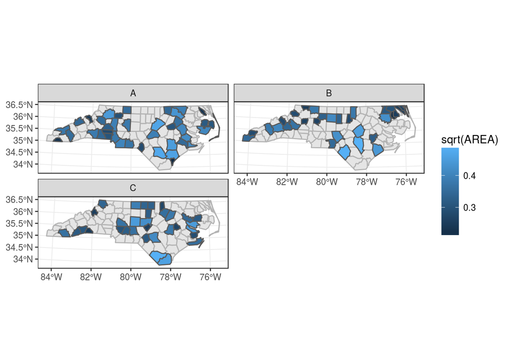

```r
# Going full fancy
p <- nc_grouped %>%
  select(-group) %>%
  ggplot() +
    geom_sf(colour = "grey70")

p +
  geom_sf(data = nc_grouped, aes(fill = sqrt(AREA))) +
  facet_wrap(~group, ncol = 2) +
  theme_bw()
```